# Predicting Palmer Penguin Sex from Physical Measurements

Author

DSCI 522 Group 36

## Summary

On the held-out test sets, our models correctly classified 32 of 37 Adélie penguins (86.5%), 16 of 17 Chinstrap penguins (94.1%), and 29 of 30 Gentoo penguins (96.7%), well above the roughly 50% accuracy of always predicting the more common sex. These results show that sexual dimorphism in body size is strong enough to classify penguin sex reliably without genetic testing. However, because some males and females overlap in size and our test sets are small, particularly for Chinstrap penguins, we recommend using the model as a quick first estimate in the field, with DNA testing reserved for birds whose predicted sex is uncertain.

## Introduction

Determining the biological sex of seabirds is essential for ecological monitoring and population modeling, as males and females often exhibit different behaviors, survival rates, and energetic demands during breeding seasons (Williams, 1995; Gorman et al., 2014). However, many penguin species are considered sexually monomorphic to the human eye, meaning males and females share identical plumage patterns and cannot be reliably distinguished visually in the field (Gorman et al., 2014).

Currently, the most reliable way to determine a penguin’s sex is through molecular testing, which requires collecting blood or feather samples, storing them in remote field conditions, and sending them to a laboratory for analysis. This process can take weeks, adds cost, and requires additional handling that can stress the birds. Observing breeding behavior can also reveal sex, but only during certain parts of the breeding season and only after long periods of observation. As a result, researchers often have to wait or rely on incomplete information when studying how males and females differ in their foraging, survival, or response to environmental change. This matters especially in Antarctica, where rapid warming along the Antarctic Peninsula may affect males and females differently, and where accurate sex ratios are needed to judge the health of breeding populations. If external body measurements can accurately predict sex, field researchers can rapidly classify individuals using simple, non-invasive calipers and scales. In this report, we ask: **Can we accurately predict the sex (male or female) of Adélie, Chinstrap, and Gentoo penguins from their bill length, bill depth, flipper length, and body mass using species-specific k-Nearest Neighbors (k-NN) classification models?**

We use the Palmer Archipelago (Antarctica) penguin dataset originally collected by Dr. Kristen Gorman and the Palmer Station Long Term Ecological Research (LTER) program (Gorman et al., 2014), and curated for data science by Horst et al. (2020). Each row in the dataset represents an individual adult penguin observed on one of three islands (Biscoe, Dream, or Torgersen) between 2007 and 2009. From the available variables, we use species (Adélie, Chinstrap, or Gentoo) to stratify our models, four continuous physical predictors (bill length and bill depth in millimeters, flipper length in millimeters, and body mass in grams), and our binary target variable, biological sex, which takes the values female or male. This dataset is well suited to our question because sex was recorded for almost every penguin, and all four measurements were taken on the same individuals. Of the 344 penguins in the dataset, 333 have both a recorded sex and complete measurements, giving us labeled examples from which a model can learn the relationship between body size and sex.

## Methods

### Data

The data were collected by Dr. Kristen Gorman and the Palmer Station Long Term Ecological Research (LTER) program between 2007 and 2009 (Gorman et al., 2014), and curated for data science as the palmerpenguins data set (Horst et al., 2020), which can be found [here](https://allisonhorst.github.io/palmerpenguins/). To ensure full reproducibility, our analysis downloads the data directly from the palmerpenguins repository and saves an unmodified copy to `data/raw/`. Observations without a recorded sex cannot be used for supervised training or evaluation, so we removed the missing rows, along with the two penguins that are missing all body measurements. This leaves 333 penguins, and we save the cleaned data to `data/processed/`.

```python
import os
from pathlib import Path

import matplotlib.pyplot as plt
import pandas as pd
import seaborn as sns
from sklearn.impute import SimpleImputer
from sklearn.metrics import classification_report
from sklearn.model_selection import GridSearchCV, train_test_split
from sklearn.neighbors import KNeighborsClassifier
from sklearn.pipeline import make_pipeline
from sklearn.preprocessing import StandardScaler

# create the data folders if they don't exist
# (git does not track empty folders)
if Path.cwd().name != "analysis":
    os.chdir("analysis")
os.makedirs("../data/raw", exist_ok=True)
os.makedirs("../data/processed", exist_ok=True)

# download the Palmer penguins data (CSV) from the palmerpenguins repository
url = "https://raw.githubusercontent.com/allisonhorst/palmerpenguins/main/inst/extdata/penguins.csv"
df_raw = pd.read_csv(url)
df_raw.to_csv("../data/raw/penguins.csv", index= False)

# keep only the variables used in the analysis and drop rows with missing
# values (penguins with no recorded sex cannot be used to train or test the model)
cols_needed = ["species", "sex", "flipper_length_mm", "bill_length_mm",
               "bill_depth_mm", "body_mass_g"]
df_clean = df_raw[cols_needed].dropna().reset_index(drop=True)
df_clean.to_csv("../data/processed/penguins_clean.csv", index=False)
```

### Analysis

To uphold the golden rule of machine learning—ensuring that test observations never influence exploratory decisions, feature scaling, or hyperparameter selection— we split the cleaned dataset into training (75%) and test (25%) subsets prior to performing any exploratory data analysis or preprocessing. Because body size differs substantially across penguin species (for instance, a female Gentoo penguin is typically heavier than a male Adelie penguin), we partition the data separately for each species using stratified random sampling to preserve equal proportions of males and females in both sets. The split data is saved in the processed folder as well with the cleaned data.

```python
# split each species before exploratory analysis
features = ["flipper_length_mm", "bill_length_mm", "bill_depth_mm", "body_mass_g"]
target = "sex"
species_list = ["Adelie", "Chinstrap", "Gentoo"]

splits = {}
train_frames, test_frames = [], []
for sp in species_list:
    sub = df_clean[df_clean["species"] == sp]
    X_train, X_test, y_train, y_test = train_test_split(
        sub[features], sub[target], test_size=0.25, stratify=sub[target], random_state=522
    )
    splits[sp] = (X_train, X_test, y_train, y_test)
    train_frames.append(X_train.assign(sex=y_train, species=sp))
    test_frames.append(X_test.assign(sex=y_test, species=sp))

train_eda = pd.concat(train_frames, ignore_index=True)
test_df = pd.concat(test_frames, ignore_index=True)
train_eda.to_csv("../data/processed/penguins_train.csv", index=False)
test_df.to_csv("../data/processed/penguins_test.csv", index=False)
```

We used a k-Nearest Neighbors (k-NN) classifier for each species (Cover & Hart, 1967), which predicts a penguin’s sex as the most common sex among the k training penguins with the most similar measurements. This suits our question because males and females form fairly distinct groups when their measurements are combined, and k-NN is simple to explain to field researchers. Because k-NN relies on distances, all four measurements were standardized (with median imputation as a safeguard against missing values) inside a pipeline, so these steps were learned from the training data only. We chose k using 5-fold cross-validation on the training set, trying odd values from 1 to 19, and used the test set only once, to evaluate the final models.

We evaluated the models using accuracy, the proportion of penguins whose sex is predicted correctly. Accuracy is appropriate because males and females are roughly balanced within each species and both types of error are equally costly; we compare it with a baseline of about 50%, the accuracy of always predicting the more common sex, and also report precision and recall for each sex. The analysis was performed in Python (Van Rossum & Drake, 2009) using requests (Reitz, 2011), pandas (McKinney, 2010), scikit-learn (Pedregosa et al., 2011), Matplotlib (Hunter, 2007), and seaborn (Waskom, 2021); the code is available at https://github.com/UBC-MDS-2026-27/DSCI-522-Group-36-Palmer-Penguins.

## Results

### Exploratory Analysis

Before building our models, we explored the training data to check whether male and female penguins differ in the four physical measurements. This step is essential to our question since if males and females had similar measurements, there would be little reason to expect a classifier to predict sex from them. All exploratory analysis uses the training set only, so the test set does not influence any of our decisions.

Table 1 shows the number of penguins and the mean of each measurement for each species and sex in the training set.

```python
summary_table = (
    train_eda.groupby(["species", "sex"])
    .agg(
        count=("body_mass_g", "size"),
        body_mass=("body_mass_g", "mean"),
        flipper_length=("flipper_length_mm", "mean"),
        bill_length=("bill_length_mm", "mean"),
        bill_depth=("bill_depth_mm", "mean"),
    )
    .round(1)
    .rename(columns={
        "count": "Count",
        "body_mass": "Body mass (g)",
        "flipper_length": "Flipper length (mm)",
        "bill_length": "Bill length (mm)",
        "bill_depth": "Bill depth (mm)",
    })
)
summary_table.index.names = ["Species", "Sex"]
sex_order = sorted(train_eda["sex"].unique())
summary_table
```

Table 1: Number of penguins and mean physical measurements by species and sex (training set).

| Species | Sex | Count | Body mass (g) | Flipper length (mm) | Bill length (mm) | Bill depth (mm) |
| --- | --- | --- | --- | --- | --- | --- |
| Adelie | female | 54 | 3368.5 | 188.2 | 37.4 | 17.6 |
|  | male | 55 | 4056.4 | 192.1 | 40.2 | 19.0 |
| Chinstrap | female | 25 | 3550.0 | 192.0 | 46.8 | 17.7 |
|  | male | 26 | 3930.8 | 199.3 | 50.9 | 19.2 |
| Gentoo | female | 43 | 4689.0 | 212.3 | 45.6 | 14.2 |
|  | male | 46 | 5454.9 | 222.0 | 49.6 | 15.8 |

Within each species, males are on average heavier than females and tend to have longer flippers, longer bills, and deeper bills. The numbers of males and females are close to equal in every species, so a model that always guessed the same sex would be correct only about half of the time; this gives a baseline of roughly 50% accuracy for our models to beat. The table also shows that Gentoo penguins are much larger than Adélie and Chinstrap penguins, which supports our decision to build a separate model for each species.

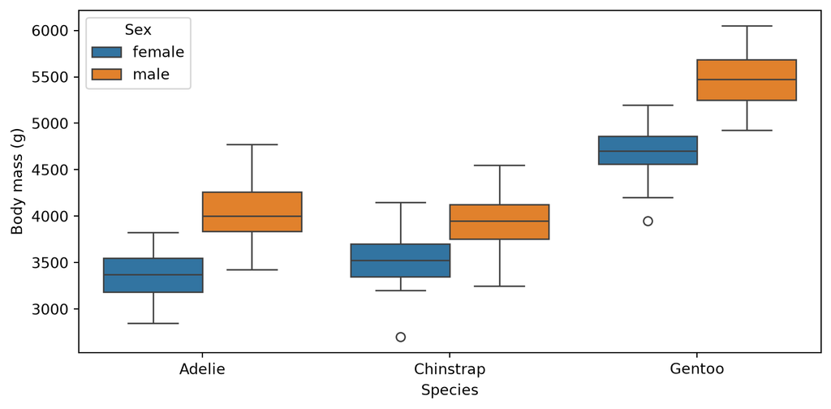

Figure 1: Body mass of female and male penguins in each species (training set). Males are heavier on average, but the ranges overlap.

```python
fig, ax = plt.subplots(figsize=(8, 4))
sns.boxplot(
    data=train_eda, x="species", y="body_mass_g", hue="sex",
    order=species_list, hue_order=sex_order, ax=ax,
)
ax.set_xlabel("Species")
ax.set_ylabel("Body mass (g)")
ax.legend(title="Sex")
plt.tight_layout()
plt.show()
```

Figure 2 shows that combining two measurements separates the sexes more clearly than one measurement on its own. When bill depth is plotted against body mass, males and females form fairly distinct groups within each species. This suggests that a model using all four measurements together should be able to predict sex well. It also motivates our choice of k-NN, which classifies a penguin based on the sex of the most similar penguins in the training data: if males and females form separate groups, a penguin’s nearest neighbors are likely to share its sex.

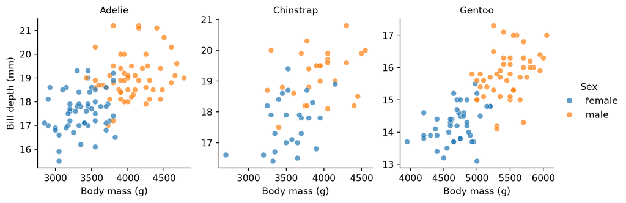

Figure 2: Bill depth against body mass for each species, colored by sex (training set). Males and females form fairly distinct groups when two measurements are combined.

```python
g = sns.relplot(
    data=train_eda, x="body_mass_g", y="bill_depth_mm", hue="sex",
    col="species", col_order=species_list, hue_order=sex_order,
    height=3.2, aspect=0.9, alpha=0.7,
    facet_kws={"sharex": False, "sharey": False},
)
g.set_axis_labels("Body mass (g)", "Bill depth (mm)")
g.set_titles("{col_name}")
g.legend.set_title("Sex")
plt.show()
```

Finally, because body mass is measured in grams (values in the thousands) while the other measurements are in millimeters (values in the tens or hundreds), the features are on very different scales. Since k-NN classifies penguins using distances between their measurements, body mass would dominate those distances if left unscaled. This is why our modeling pipeline standardizes all four measurements before fitting the classifier.

### Model

```python
#Question: Can we predict a penguin's sex from its measurements (flipper length, bill length, bill depth, body mass) using k-NN

pipe = make_pipeline(
    SimpleImputer(strategy="median"),
    StandardScaler(),
    KNeighborsClassifier(),
)
param_grid = {"kneighborsclassifier__n_neighbors": range(1, 20, 2)}

results = []

for species in ["Adelie", "Chinstrap", "Gentoo"]:
    #reuse the training/test split made in Methods
    X_train, X_test, y_train, y_test = splits[species]

    grid = GridSearchCV(pipe, param_grid=param_grid, cv=5, scoring="accuracy")
    grid.fit(X_train, y_train)

    best_k = grid.best_params_["kneighborsclassifier__n_neighbors"]
    test_acc = grid.score(X_test, y_test)
    y_pred = grid.predict(X_test)

    results.append({"Species": species, "Best k": best_k, "CV Accuracy": round(grid.best_score_, 3), "Test Accuracy": round(test_acc, 3),
                    "Correct": int((y_pred == y_test).sum()), "Test size": len(y_test)})

    print(f"=== {species} (Best k={best_k}) ===")
    print(classification_report(y_test, y_pred))
```

```
=== Adelie (Best k=9) ===
              precision    recall  f1-score   support

      female       0.85      0.89      0.87        19
        male       0.88      0.83      0.86        18

    accuracy                           0.86        37
   macro avg       0.87      0.86      0.86        37
weighted avg       0.87      0.86      0.86        37

=== Chinstrap (Best k=9) ===
              precision    recall  f1-score   support

      female       1.00      0.89      0.94         9
        male       0.89      1.00      0.94         8

    accuracy                           0.94        17
   macro avg       0.94      0.94      0.94        17
weighted avg       0.95      0.94      0.94        17

=== Gentoo (Best k=9) ===
              precision    recall  f1-score   support

      female       0.94      1.00      0.97        15
        male       1.00      0.93      0.97        15

    accuracy                           0.97        30
   macro avg       0.97      0.97      0.97        30
weighted avg       0.97      0.97      0.97        30
```

```python
# Summary comparison table across all 3 species
summary_df = pd.DataFrame(results)
summary_df
```

Table 2: Selected number of neighbors, cross-validation (CV) accuracy, and test accuracy for each species.

|  | Species | Best k | CV Accuracy | Test Accuracy | Correct | Test size |
| --- | --- | --- | --- | --- | --- | --- |
| 0 | Adelie | 9 | 0.945 | 0.865 | 32 | 37 |
| 1 | Chinstrap | 9 | 0.900 | 0.941 | 16 | 17 |
| 2 | Gentoo | 9 | 0.944 | 0.967 | 29 | 30 |

## Discussion

Our results confirm that external physical measurements can accurately predict the biological sex of adult Palmer penguins when stratified by species, achieving high held-out test accuracies for all penguins. Our findings directly answer our research question by demonstrating that bill length, bill depth, flipper length, and body mass carry sufficient sex-specific signal to classify male and female penguins reliably. These results are consistent with our exploratory analysis, which showed that males are larger than females on average in every species (Table 1) and that the sexes form fairly distinct groups when measurements are combined (Figure 2). The remaining errors are also expected: Figure 1 showed that the body sizes of males and females overlap, so a small male or a large female can be misclassified however well the model is tuned.

Despite strong performance, several methodological assumptions and limitations must be considered. First, our workflow assumes that a penguin’s species is already known before predicting its sex; while visual species identification is straightforward in the field due to distinct head markings, any species misidentification would degrade sex classification accuracy. Second, stratifying the dataset by species reduced our sample sizes, leaving only 17 Chinstrap penguins in the test set, where a single misclassification shifts test accuracy by nearly six percentage points. Third, because k-Nearest Neighbors relies on Euclidean distances across physical measurements, seasonal weight fluctuations, such as mass loss during fasting and incubation, or regional size differences could shift feature distributions and reduce accuracy if the model is applied outside the Palmer Archipelago without local recalibration.

The broader impact of this approach lies in making wildlife demographic monitoring faster, cheaper, and less invasive. Accurate sex ratios are critical for estimating breeding population viability and detecting sex-biased mortality from climate change or fisheries interactions.

For future work, it would be interesting to test if we can still predict sex accurately without using body mass, since weight changes so much across seasons—for example, by using bill shape ratios or island location instead. Researchers could also compare k-Nearest Neighbors with models like logistic regression to get probability scores, which would help biologists see when a prediction is uncertain and needs a DNA test to be sure.

## References

Cover, T., & Hart, P. (1967). Nearest neighbor pattern classification. *IEEE Transactions on Information Theory*, 13(1), 21–27. https://doi.org/10.1109/TIT.1967.1053964

Gorman, K. B., Williams, T. D., & Fraser, W. R. (2014). Ecological sexual dimorphism and environmental variability within a community of Antarctic penguins (genus *Pygoscelis*). *PLoS ONE*, 9(3), e90081. https://doi.org/10.1371/journal.pone.0090081

Horst, A. M., Hill, A. P., & Gorman, K. B. (2020). *palmerpenguins: Palmer Archipelago (Antarctica) penguin data* (R package version 0.1.0). https://allisonhorst.github.io/palmerpenguins/

Hunter, J. D. (2007). Matplotlib: A 2D graphics environment. *Computing in Science & Engineering*, 9(3), 90–95. https://doi.org/10.1109/MCSE.2007.55

McKinney, W. (2010). Data structures for statistical computing in Python. In *Proceedings of the 9th Python in Science Conference* (pp. 56–61). https://doi.org/10.25080/Majora-92bf1922-00a

Pedregosa, F., Varoquaux, G., Gramfort, A., Michel, V., Thirion, B., Grisel, O., Blondel, M., Prettenhofer, P., Weiss, R., Dubourg, V., Vanderplas, J., Passos, A., Cournapeau, D., Brucher, M., Perrot, M., & Duchesnay, É. (2011). Scikit-learn: Machine learning in Python. *Journal of Machine Learning Research*, 12, 2825–2830.

Reitz, K. (2011). Requests: HTTP for humans. https://requests.readthedocs.io/

Van Rossum, G., & Drake, F. L. (2009). *Python 3 reference manual*. CreateSpace.

Waskom, M. L. (2021). seaborn: Statistical data visualization. *Journal of Open Source Software*, 6(60), 3021. https://doi.org/10.21105/joss.03021

Williams, T. D. (1995). *The penguins: Spheniscidae*. Oxford University Press.